# Mixed Effects Logistic Regression

## Binomial Generalized Linear Mixed Models (binomial GLMMs), are useful for modeling binary outcomes “Different type of treatments” (RT/BI/BT)" for clustered measures (SEX/VET/DEPLOY/HISPANIC/RACE). For example, let’s say first we design a study that tracks what treatment (RT for example), if DAST score is high/low. Using a binomial GLMM we could model the probability of taking treatment given various predictors such as SEX and RACE of the audience, and/or some “treatment” we applied to a subset of the audiences, such as SCREEN/INJECT class.

```r
library(crayon)
library(knitr)    # For knitting document and include_graphics function
library(ggplot2)  # For plotting
library(png)
library(usdm)
library(ggplot2)
library(jtools)
library(lares)
require(GGally)
library(readxl)
library(dplyr)
library(caret)
library(lattice)
library(rpart)
library(glmnet)
library(Matrix)
library(caret)
library(car)
set.seed(16)

data<- read.csv(file ="final_2.csv",header=T)
data=na.omit(data)
drop <- c("X","HALLUC","BIRTH","METHADONE","OTHERDRUGS","ID","SCREEN" )
data = data[,!(names(data) %in% drop)]
colnames(data)
```

```
##  [1] "DAST"          "SEX"           "HISPANIC"      "RACE"
##  [5] "VET"           "ACTIVE"        "DEPLOY"        "AUDIT"
##  [9] "COSCREEN"      "BI"            "BT"            "RT"
## [13] "ANYALC"        "BINGEDAYS"     "DRUGDAYS"      "ALCDRUGS"
## [17] "DAYSCOCAINE"   "MARYJDAYS"     "ANYOPIATEDAYS" "METHDAYS"
## [21] "INJECT"        "AGE"           "TOBMONTH"
```

## vtree is a flexible tool for calculating and displaying variable trees — diagrams that show information about nested subsets of a data frame. vtree can be used to:

## 1) explore a data set interactively

## 2) produce customized figures for reports and publications.

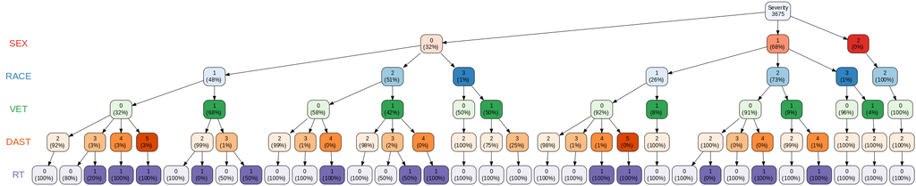

```r
library(vtree)
png(file="saving_plot2.png",
width=600, height=350)
vtree(data, c(  "SEX", "RACE","VET","DAST","RT"),
    showcount = FALSE,"Severity",
   horiz = FALSE)
```

### Creating dummy variables for the catogrical features

```r
sub_data<- subset(data, select = c( "DAST","SEX","HISPANIC","RACE","VET","ACTIVE","DEPLOY","AUDIT","COSCREEN","RT","ANYALC","BINGEDAYS" ,
"DRUGDAYS","ALCDRUGS","DAYSCOCAINE" ,"MARYJDAYS","ANYOPIATEDAYS" ,"METHDAYS","INJECT","AGE","TOBMONTH"   ))
sub_data=na.omit(sub_data)
sub_data<- within(sub_data, {
COSCREEN <- factor(COSCREEN)
SEX <- factor(SEX)
RT<- factor(RT)
VET<- factor(VET)
DAST<- factor(DAST)
AUDIT<- factor(AUDIT)
RACE<- factor(RACE)
INJECT<- factor(INJECT)
VET<- factor(VET)
HISPANIC<- factor(HISPANIC)
DEPLOY<- factor(DEPLOY)
ACTIVE<- factor(ACTIVE)
TOBMONTH<- factor(TOBMONTH)

})
nrow(sub_data)
```

```
## [1] 3675
```

### Top 20 correlation for RT

### This function creates a correlation full study and returns a rank of the highest correlation variables obtained in a cross-table.

```r
corr_var(data, # name of dataset
  RT, # name of variable to focus on
  top = 20, ranks = TRUE
)
```

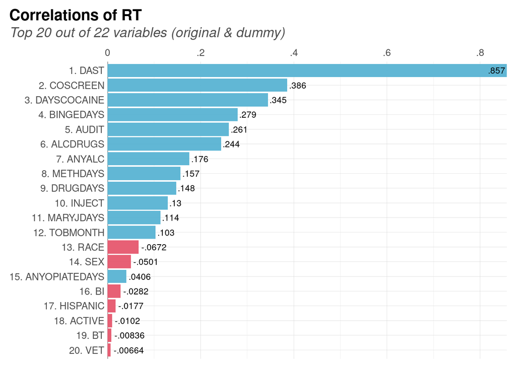

### Display top 20 pairs of our features (by correlation coefficient)

```r
corr_cross(sub_data, # name of dataset
    top = 20 )
```

```
## Returning only the top 20. You may override with the 'top' argument
```

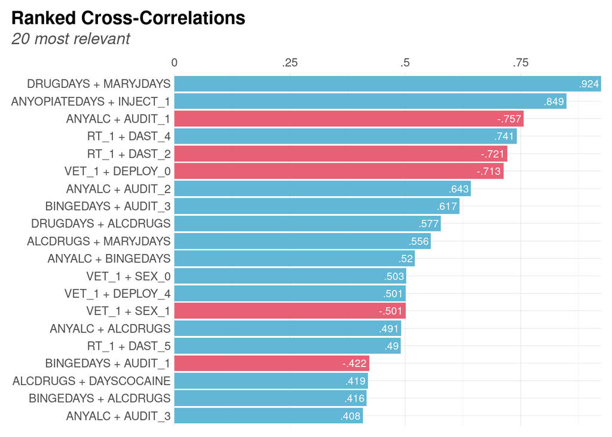

**********************************************************************************************************************************************************************************************************************************************************************

### Unbalanced classification causes problems to many learning algorithms. These problems are characterized by the uneven proportion of cases that are available for each class of the problem. SMOTE method handles unbalanced classification problem. Namely, it can generate a new “SMOTEd” data set that addresses the class unbalance problem.

```r
library(DMwR)
newdata <- SMOTE(RT ~ ., sub_data, perc.over = 8000, k = 5, perc.under =105)

as.data.frame(table(newdata $RT))
```

| Var1 | Freq |
| --- | --- |
| 0 | 2436 |
| 1 | 2349 |

```r
sum(newdata['RT']==1)
```

```
## [1] 2349
```

```r
sum(newdata['RT']==0)
```

```
## [1] 2436
```

## Fixed effects logistic regression (dependent variable is binary).

## Regressions are used when we try to understand how independent variables correlate with a dependent or outcome variable. So, if we want to investigate how a certain factor (RT) affects an outcome, then a regression is the way to go.

## A) FLat Case

```r
flat_model <- glm(RT~DAST+SEX+HISPANIC+RACE+VET+ACTIVE+DEPLOY+AUDIT+COSCREEN+ANYALC+BINGEDAYS+DRUGDAYS+ALCDRUGS+DAYSCOCAINE+MARYJDAYS+ANYOPIATEDAYS+METHDAYS+INJECT+AGE+TOBMONTH, data = newdata, family = binomial(link = "logit"))
summary(flat_model)
```

```
##
## Call:
## glm(formula = RT ~ DAST + SEX + HISPANIC + RACE + VET + ACTIVE +
##     DEPLOY + AUDIT + COSCREEN + ANYALC + BINGEDAYS + DRUGDAYS +
##     ALCDRUGS + DAYSCOCAINE + MARYJDAYS + ANYOPIATEDAYS + METHDAYS +
##     INJECT + AGE + TOBMONTH, family = binomial(link = "logit"),
##     data = newdata)
##
## Deviance Residuals:
##     Min       1Q   Median       3Q      Max
## -3.4066  -0.0105   0.0000   0.0000   2.7411
##
## Coefficients:
##                 Estimate Std. Error z value Pr(>|z|)
## (Intercept)   -9.324e+00  2.853e+00  -3.268 0.001083 **
## DAST3          7.394e+00  1.383e+00   5.347 8.97e-08 ***
## DAST4          4.244e+01  9.736e+03   0.004 0.996522
## DAST5          3.207e+01  5.911e+03   0.005 0.995672
## SEX1          -1.907e+00  9.438e-01  -2.020 0.043336 *
## SEX2          -2.595e+01  1.228e+05   0.000 0.999831
## HISPANIC1     -1.816e+01  3.360e+04  -0.001 0.999569
## RACE2          7.715e-02  9.506e-01   0.081 0.935317
## RACE3         -1.925e+01  8.236e+04   0.000 0.999814
## VET1           1.314e+00  1.101e+00   1.193 0.232719
## ACTIVE1       -8.734e+01  2.366e+05   0.000 0.999705
## DEPLOY1       -2.108e+01  3.672e+04  -0.001 0.999542
## DEPLOY2       -2.246e+00  5.559e+00  -0.404 0.686132
## DEPLOY3       -2.703e+01  7.190e+04   0.000 0.999700
## DEPLOY4       -1.111e+01  7.458e+00  -1.490 0.136324
## DEPLOY5        2.066e+00  1.439e+00   1.436 0.150939
## AUDIT2        -3.144e+01  7.857e+03  -0.004 0.996807
## AUDIT3         6.722e+00  1.725e+00   3.898 9.72e-05 ***
## COSCREEN1      2.441e+00  8.869e-01   2.752 0.005924 **
## ANYALC        -2.532e-01  1.117e-01  -2.267 0.023414 *
## BINGEDAYS      1.473e+00  3.831e-01   3.845 0.000121 ***
## DRUGDAYS       3.673e-02  3.080e-01   0.119 0.905069
## ALCDRUGS       1.236e+00  3.788e-01   3.263 0.001103 **
## DAYSCOCAINE    1.643e+01  2.981e+03   0.006 0.995601
## MARYJDAYS     -3.954e-02  3.069e-01  -0.129 0.897487
## ANYOPIATEDAYS -5.274e+01  9.303e+03  -0.006 0.995477
## METHDAYS      -1.215e-02  2.952e-01  -0.041 0.967170
## INJECT1        2.920e+00  1.192e+04   0.000 0.999805
## AGE            4.091e-02  4.216e-02   0.971 0.331793
## TOBMONTH1     -5.536e-01  1.117e+00  -0.496 0.620070
## ---
## Signif. codes:  0 '***' 0.001 '**' 0.01 '*' 0.05 '.' 0.1 ' ' 1
##
## (Dispersion parameter for binomial family taken to be 1)
##
##     Null deviance: 6631.837  on 4784  degrees of freedom
## Residual deviance:   67.125  on 4755  degrees of freedom
## AIC: 127.12
##
## Number of Fisher Scoring iterations: 25
```

## That means these features less likely affect RT comparing to other features. The model does get so cluttered it’s hard to figure out what’s going on, and it makes sense to eliminate effects that aren’t serving a purpose, but even insignificant effects can have a purpose. So there are situations where there is a purpose in showing that specific predictors were not significant and to measure their coefficient anyway. Expected control variables. You need to show that you’ve controlled for them. There are control variables that everyone expects to see in medical studies and sociological studies; such as Socioeconomic status, race, income, education , and age. If we take these expected controls out, you will just get criticism for not including them. And it may be interesting to show that in this sample and with these variables, these controls weren’t significant.

# B) Flat Case

```r
flat_model1 <- glm(RT~DAST+SEX+AUDIT+ANYALC+BINGEDAYS+DAYSCOCAINE+MARYJDAYS+METHDAYS+AGE, data = newdata, family = binomial(link = "logit"))
summary(flat_model1)
```

```
##
## Call:
## glm(formula = RT ~ DAST + SEX + AUDIT + ANYALC + BINGEDAYS +
##     DAYSCOCAINE + MARYJDAYS + METHDAYS + AGE, family = binomial(link = "logit"),
##     data = newdata)
##
## Deviance Residuals:
##     Min       1Q   Median       3Q      Max
## -6.4770  -0.0461   0.0000   0.0000   3.1693
##
## Coefficients:
##               Estimate Std. Error z value Pr(>|z|)
## (Intercept) -8.196e+00  1.293e+00  -6.340 2.30e-10 ***
## DAST3        6.756e+00  5.923e-01  11.407  < 2e-16 ***
## DAST4        3.848e+01  4.896e+04   0.001  0.99937
## DAST5        3.057e+01  6.510e+03   0.005  0.99625
## SEX1        -7.620e-01  5.267e-01  -1.447  0.14797
## SEX2        -2.181e+01  1.499e+05   0.000  0.99988
## AUDIT2      -2.784e+01  4.845e+04  -0.001  0.99954
## AUDIT3       3.914e+00  7.488e-01   5.228 1.72e-07 ***
## ANYALC       1.124e-01  3.820e-02   2.943  0.00325 **
## BINGEDAYS    4.914e-01  9.325e-02   5.269 1.37e-07 ***
## DAYSCOCAINE  1.863e+01  1.651e+03   0.011  0.99100
## MARYJDAYS    3.950e-02  4.471e-02   0.884  0.37693
## METHDAYS     4.515e-02  7.266e-02   0.621  0.53440
## AGE          4.824e-02  1.997e-02   2.415  0.01574 *
## ---
## Signif. codes:  0 '***' 0.001 '**' 0.01 '*' 0.05 '.' 0.1 ' ' 1
##
## (Dispersion parameter for binomial family taken to be 1)
##
##     Null deviance: 6631.84  on 4784  degrees of freedom
## Residual deviance:  161.82  on 4771  degrees of freedom
## AIC: 189.82
##
## Number of Fisher Scoring iterations: 25
```

### Results show in Flat Case (B) AGE is significant although Flat Case (A) model shows it is not. That means some of these features have strong correlation with each other. So here in this case flatted model is not the best choice, since we have clustered data. In this regard, using a standard regression to quantify the impact of different features on treatments can be misleading, as different groups can exist within each feature that impacts treatments in a different way. Therefore, a mechanism is needed to model structured linear relationships in an appropriate way.

## qqplot, points should more or less trace the line.

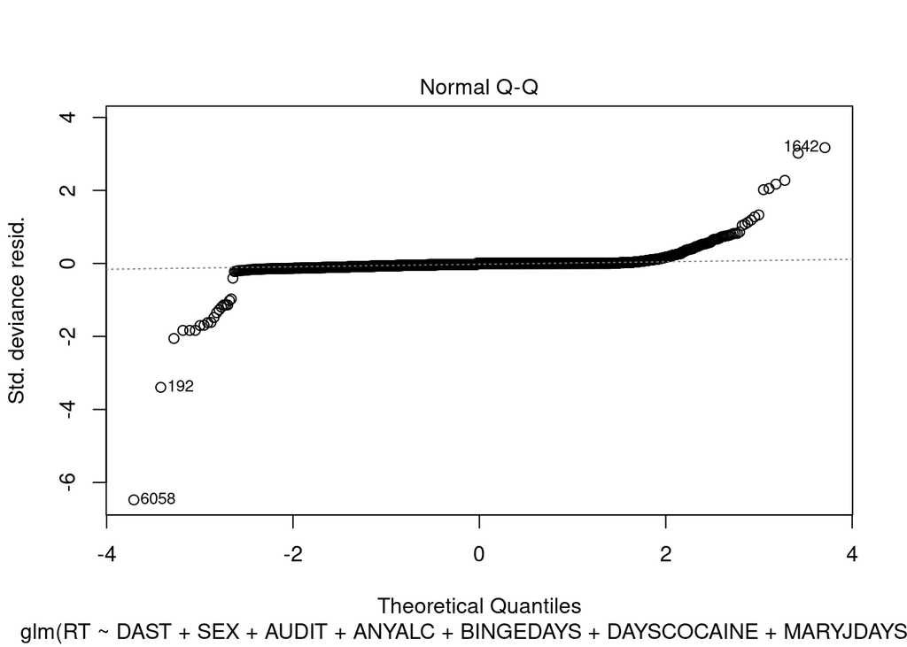

```r
plot(flat_model1, which = 2)
```

## To interpret the value of the parameter estimates, we need to exponentiate the estimates. The summ function from the jtools packages provides an easy to do so for any model fitted by glm. See below.

```r
summ(flat_model1, exp = T) # set "exp = T" to show esponentiated estimates; if you need standardised estimaets, set "scale = T"
```

```
## MODEL INFO:
## Observations: 4785
## Dependent Variable: RT
## Type: Generalized linear model
##   Family: binomial
##   Link function: logit
##
## MODEL FIT:
## χ²(13) = 6470.01, p = 0.00
## Pseudo-R² (Cragg-Uhler) = 0.99
## Pseudo-R² (McFadden) = 0.98
## AIC = 189.82, BIC = 280.45
##
## Standard errors: MLE
## ---------------------------------------------------------------------------
##                                exp(Est.)     2.5%     97.5%   z val.      p
## ----------------- ---------------------- -------- --------- -------- ------
## (Intercept)                         0.00     0.00      0.00    -6.34   0.00
## DAST3                             859.58   269.22   2744.49    11.41   0.00
## DAST4               51657522950715368.00     0.00       Inf     0.00   1.00
## DAST5                  18913725792083.00     0.00       Inf     0.00   1.00
## SEX1                                0.47     0.17      1.31    -1.45   0.15
## SEX2                                0.00     0.00       Inf    -0.00   1.00
## AUDIT2                              0.00     0.00       Inf    -0.00   1.00
## AUDIT3                             50.12    11.55    217.47     5.23   0.00
## ANYALC                              1.12     1.04      1.21     2.94   0.00
## BINGEDAYS                           1.63     1.36      1.96     5.27   0.00
## DAYSCOCAINE                 123356458.96     0.00       Inf     0.01   0.99
## MARYJDAYS                           1.04     0.95      1.14     0.88   0.38
## METHDAYS                            1.05     0.91      1.21     0.62   0.53
## AGE                                 1.05     1.01      1.09     2.41   0.02
## ---------------------------------------------------------------------------
```

```r
library(arm)
```

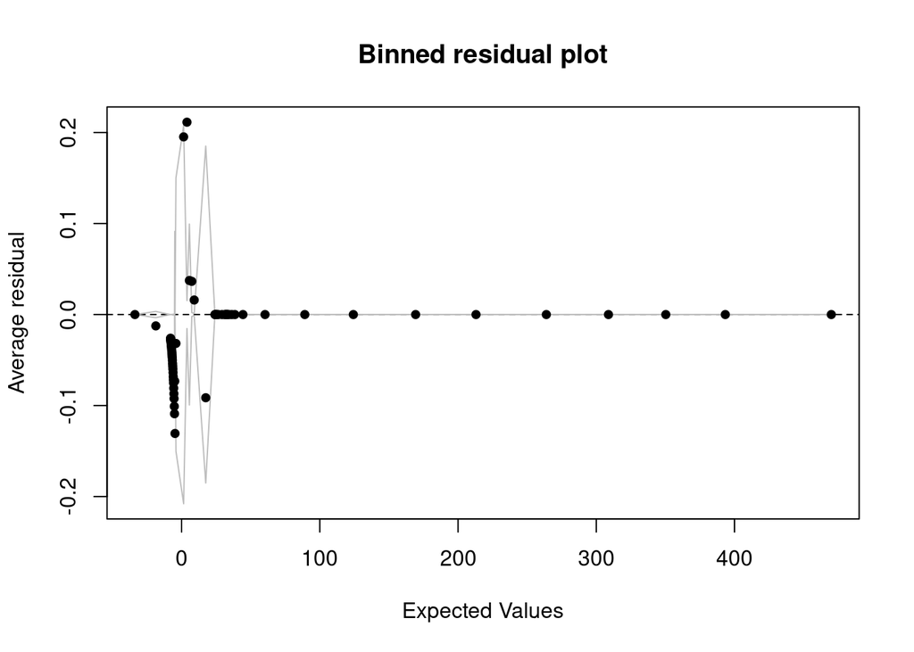

```r
x <- predict(flat_model1 )
y <- resid(flat_model1 )
binnedplot(x,y)
```

## **************** Mixed Effects Models for Clustered Data *********************

## The general work flow we’ll be following:

## 1) Select dependent variable. In this case, we’re interested in whether or not someone took treatment.

## 2) Select fixed variables.

## 3) Select random variables.

## 4) Fit a model. Also make sure to check regression assumptions.

## 5) Check for intra class correlation of random variables. Make sure that the groups we’re using as random variables actually tend to group together.

## 6) Analyze model output. Figure out what we’ve learned from our model.

first: We want to study how specific fixed features affects the received referral to treatment (RT) in the three types of audiences’ gender

```r
corr_var(newdata, # name of dataset
 SEX, # name of variable to focus on
  top = 15  # display top 5 correlations
)
```

```
## Automatically using 'SEX_0
```

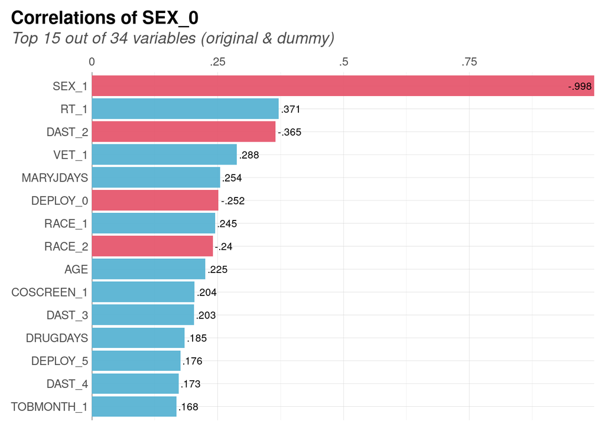

```r
library(car)

(ans <-powerTransform(cbind(AGE) ~ 1, data=newdata))
```

```
## Estimated transformation parameter
##       Y1
## 0.388785
```

```r
summary(ans)
```

```
## bcPower Transformation to Normality
##    Est Power Rounded Pwr Wald Lwr Bnd Wald Upr Bnd
## Y1    0.3888        0.33       0.3124       0.4652
##
## Likelihood ratio test that transformation parameter is equal to 0
##  (log transformation)
##                            LRT df       pval
## LR test, lambda = (0) 99.46069  1 < 2.22e-16
##
## Likelihood ratio test that no transformation is needed
##                            LRT df       pval
## LR test, lambda = (1) 244.1991  1 < 2.22e-16
```

### Consider sex as random group intercept (1|SEX)

```r
m1 <- glmer(RT~DAST+AUDIT+ANYALC+log(AGE)+ALCDRUGS+BINGEDAYS+COSCREEN+
    (1 | SEX), data =newdata, family =  binomial(link = "logit"))
summary(m1)
```

```
## Generalized linear mixed model fit by maximum likelihood (Laplace
##   Approximation) [glmerMod]
##  Family: binomial  ( logit )
## Formula: RT ~ DAST + AUDIT + ANYALC + log(AGE) + ALCDRUGS + BINGEDAYS +
##     COSCREEN + (1 | SEX)
##    Data: newdata
##
##      AIC      BIC   logLik deviance df.resid
##    172.9    250.6    -74.4    148.9     4773
##
## Scaled residuals:
##      Min       1Q   Median       3Q      Max
## -239.248   -0.025   -0.007    0.000    4.868
##
## Random effects:
##  Groups Name        Variance Std.Dev.
##  SEX    (Intercept) 0.1075   0.3278
## Number of obs: 4785, groups:  SEX, 3
##
## Fixed effects:
##               Estimate Std. Error z value Pr(>|z|)
## (Intercept)  -20.35438    4.58839  -4.436 9.16e-06 ***
## DAST3          6.66161    0.68146   9.775  < 2e-16 ***
## DAST4         24.88501  439.28335   0.057 0.954825
## DAST5         29.31426 5690.02120   0.005 0.995889
## AUDIT2        -3.40473    1.13335  -3.004 0.002663 **
## AUDIT3         3.47180    0.79805   4.350 1.36e-05 ***
## ANYALC         0.17141    0.05192   3.301 0.000962 ***
## log(AGE)       3.58560    1.10348   3.249 0.001157 **
## ALCDRUGS      -0.14355    0.11487  -1.250 0.211414
## BINGEDAYS      0.34397    0.07349   4.681 2.86e-06 ***
## COSCREEN1      2.67655    0.65115   4.111 3.95e-05 ***
## ---
## Signif. codes:  0 '***' 0.001 '**' 0.01 '*' 0.05 '.' 0.1 ' ' 1
##
## Correlation of Fixed Effects:
##           (Intr) DAST3  DAST4  DAST5  AUDIT2 AUDIT3 ANYALC l(AGE) ALCDRU BINGED
## DAST3     -0.505
## DAST4     -0.001  0.001
## DAST5      0.000  0.000  0.000
## AUDIT2    -0.015  0.057  0.000  0.000
## AUDIT3    -0.351  0.300  0.000  0.000  0.259
## ANYALC    -0.271  0.164  0.001  0.000 -0.267 -0.249
## log(AGE)  -0.994  0.455  0.001  0.000  0.016  0.333  0.251
## ALCDRUGS   0.220 -0.441 -0.001  0.000 -0.036  0.092 -0.622 -0.205
## BINGEDAYS -0.156  0.286  0.000  0.000 -0.126  0.047 -0.299  0.135  0.136
## COSCREEN1 -0.309  0.056  0.000  0.000 -0.148 -0.040  0.129  0.296 -0.132 -0.045
## optimizer (Nelder_Mead) convergence code: 0 (OK)
## unable to evaluate scaled gradient
## Model failed to converge: degenerate  Hessian with 2 negative eigenvalues
```

```r
(0.4753/(0.4753+pi^2/3))*100
```

```
## [1] 12.62361
```

## mean preduction

```r
predictions <- predict(m1, type = "response")
mean(predictions)
```

```
## [1] 0.490903
```

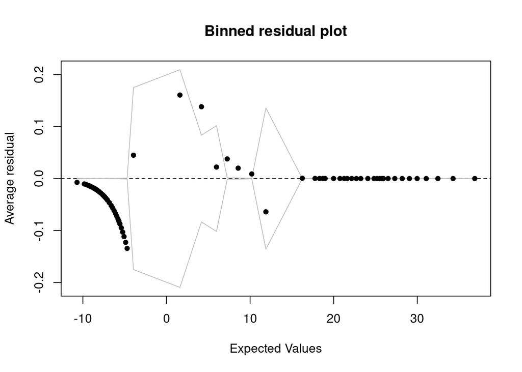

```r
library(arm)
x <- predict(m1)
y <- resid(m1)
binnedplot(x,y)
```

```r
library(car)
Anova(m1,type="II",test.statistic="Chisq")
```

|  | Chisq | Df | Pr(>Chisq) |
| --- | --- | --- | --- |
| DAST | 95.561476 | 3 | 1.398447e-20 |
| AUDIT | 37.214006 | 2 | 8.300061e-09 |
| ANYALC | 10.898596 | 1 | 9.623716e-04 |
| log(AGE) | 10.558438 | 1 | 1.156589e-03 |
| ALCDRUGS | 1.561719 | 1 | 2.114137e-01 |
| BINGEDAYS | 21.908881 | 1 | 2.859077e-06 |
| COSCREEN | 16.896236 | 1 | 3.947979e-05 |

```r
coef(m1)
```

```
## $SEX
##   (Intercept)    DAST3    DAST4    DAST5    AUDIT2   AUDIT3    ANYALC log(AGE)
## 0   -20.13432 6.661605 24.88501 29.31426 -3.404728 3.471797 0.1714106 3.585605
## 1   -20.57012 6.661605 24.88501 29.31426 -3.404728 3.471797 0.1714106 3.585605
## 2   -20.35555 6.661605 24.88501 29.31426 -3.404728 3.471797 0.1714106 3.585605
##     ALCDRUGS BINGEDAYS COSCREEN1
## 0 -0.1435456 0.3439671  2.676553
## 1 -0.1435456 0.3439671  2.676553
## 2 -0.1435456 0.3439671  2.676553
##
## attr(,"class")
## [1] "coef.mer"
```

```r
residuals <- resid(m1)
summary(residuals)
```

```
##      Min.   1st Qu.    Median      Mean   3rd Qu.      Max.
## -4.680816 -0.035965 -0.009469 -0.017877  0.000017  2.532481
```

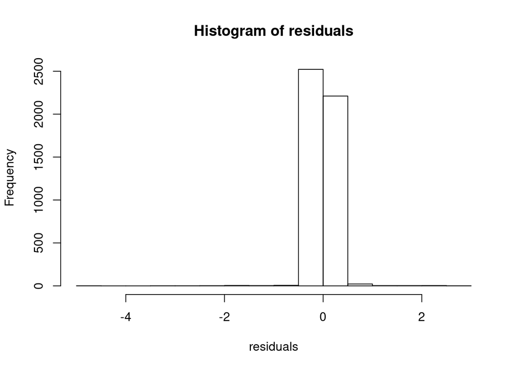

```r
hist(residuals)
```

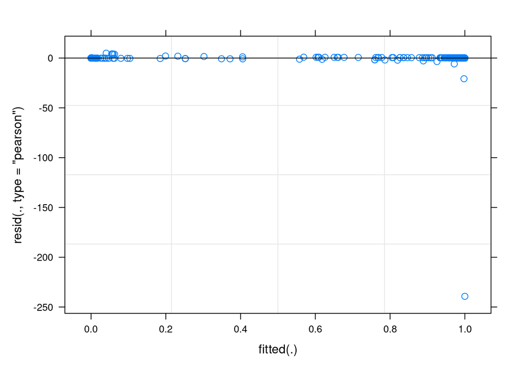

```r
plot(m1, which = 2)
```

## Second: intercept varying among SEX within VET (nested random effects)

```r
m2 <- glmer(RT~DAST+AUDIT+ANYALC+log(AGE)+ALCDRUGS+BINGEDAYS+COSCREEN+(1|VET:SEX)+(1|SEX), data =newdata, family =binomial(link = "logit"))
```

```
## boundary (singular) fit: see ?isSingular
```

```r
summary(m2)
```

```
## Generalized linear mixed model fit by maximum likelihood (Laplace
##   Approximation) [glmerMod]
##  Family: binomial  ( logit )
## Formula: RT ~ DAST + AUDIT + ANYALC + log(AGE) + ALCDRUGS + BINGEDAYS +
##     COSCREEN + (1 | VET:SEX) + (1 | SEX)
##    Data: newdata
##
##      AIC      BIC   logLik deviance df.resid
##    174.9    259.0    -74.4    148.9     4772
##
## Scaled residuals:
##      Min       1Q   Median       3Q      Max
## -239.169   -0.025   -0.007    0.000    4.868
##
## Random effects:
##  Groups  Name        Variance Std.Dev.
##  VET:SEX (Intercept) 0.0000   0.0000
##  SEX     (Intercept) 0.1075   0.3279
## Number of obs: 4785, groups:  VET:SEX, 5; SEX, 3
##
## Fixed effects:
##               Estimate Std. Error z value Pr(>|z|)
## (Intercept)  -20.36117    4.53664  -4.488 7.18e-06 ***
## DAST3          6.66201    0.69440   9.594  < 2e-16 ***
## DAST4         36.01232 1024.16303   0.035 0.971950
## DAST5         36.04898  724.13546   0.050 0.960296
## AUDIT2        -3.40480    1.13496  -3.000 0.002700 **
## AUDIT3         3.47218    0.79518   4.367 1.26e-05 ***
## ANYALC         0.17143    0.05161   3.322 0.000894 ***
## log(AGE)       3.58723    1.09048   3.290 0.001003 **
## ALCDRUGS      -0.14358    0.11411  -1.258 0.208287
## BINGEDAYS      0.34399    0.07343   4.685 2.81e-06 ***
## COSCREEN1      2.67693    0.65855   4.065 4.81e-05 ***
## ---
## Signif. codes:  0 '***' 0.001 '**' 0.01 '*' 0.05 '.' 0.1 ' ' 1
##
## Correlation of Fixed Effects:
##           (Intr) DAST3  DAST4  DAST5  AUDIT2 AUDIT3 ANYALC l(AGE) ALCDRU BINGED
## DAST3     -0.481
## DAST4     -0.014  0.009
## DAST5     -0.009  0.007  0.000
## AUDIT2    -0.012  0.075  0.004  0.002
## AUDIT3    -0.345  0.304  0.015  0.010  0.263
## ANYALC    -0.268  0.146 -0.001  0.000 -0.271 -0.251
## log(AGE)  -0.994  0.437  0.013  0.008  0.015  0.329  0.247
## ALCDRUGS   0.218 -0.424 -0.001 -0.001 -0.029  0.094 -0.621 -0.203
## BINGEDAYS -0.154  0.299  0.002  0.002 -0.114  0.051 -0.302  0.135  0.134
## COSCREEN1 -0.306  0.007  0.003  0.002 -0.161 -0.054  0.131  0.290 -0.129 -0.061
## optimizer (Nelder_Mead) convergence code: 0 (OK)
## boundary (singular) fit: see ?isSingular
```

## according the results VET:SEX does not has effect on the RT because the variance of random factor of VET:SEX equals 0

```r
predictions <- predict(m2, type = "response")
mean(predictions)
```

```
## [1] 0.4909029
```

```r
coef(m2)
```

```
## $`VET:SEX`
##     (Intercept)   DAST3    DAST4    DAST5    AUDIT2   AUDIT3    ANYALC log(AGE)
## 0:0   -20.36117 6.66201 36.01232 36.04898 -3.404798 3.472178 0.1714311  3.58723
## 0:1   -20.36117 6.66201 36.01232 36.04898 -3.404798 3.472178 0.1714311  3.58723
## 0:2   -20.36117 6.66201 36.01232 36.04898 -3.404798 3.472178 0.1714311  3.58723
## 1:0   -20.36117 6.66201 36.01232 36.04898 -3.404798 3.472178 0.1714311  3.58723
## 1:1   -20.36117 6.66201 36.01232 36.04898 -3.404798 3.472178 0.1714311  3.58723
##       ALCDRUGS BINGEDAYS COSCREEN1
## 0:0 -0.1435812 0.3439939  2.676932
## 0:1 -0.1435812 0.3439939  2.676932
## 0:2 -0.1435812 0.3439939  2.676932
## 1:0 -0.1435812 0.3439939  2.676932
## 1:1 -0.1435812 0.3439939  2.676932
##
## $SEX
##   (Intercept)   DAST3    DAST4    DAST5    AUDIT2   AUDIT3    ANYALC log(AGE)
## 0   -20.14104 6.66201 36.01232 36.04898 -3.404798 3.472178 0.1714311  3.58723
## 1   -20.57696 6.66201 36.01232 36.04898 -3.404798 3.472178 0.1714311  3.58723
## 2   -20.36235 6.66201 36.01232 36.04898 -3.404798 3.472178 0.1714311  3.58723
##     ALCDRUGS BINGEDAYS COSCREEN1
## 0 -0.1435812 0.3439939  2.676932
## 1 -0.1435812 0.3439939  2.676932
## 2 -0.1435812 0.3439939  2.676932
##
## attr(,"class")
## [1] "coef.mer"
```

```r
residuals <- resid(m2)
summary(residuals)
```

```
##     Min.  1st Qu.   Median     Mean  3rd Qu.     Max.
## -4.68067 -0.03595 -0.00946 -0.01789  0.00000  2.53247
```

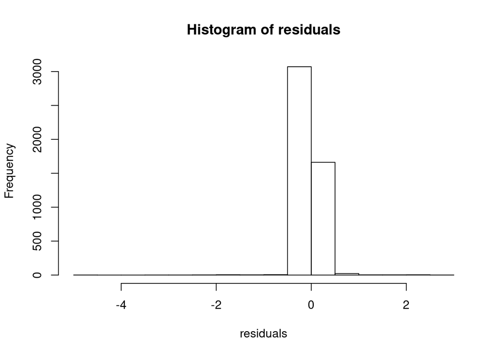

```r
hist(residuals)
```

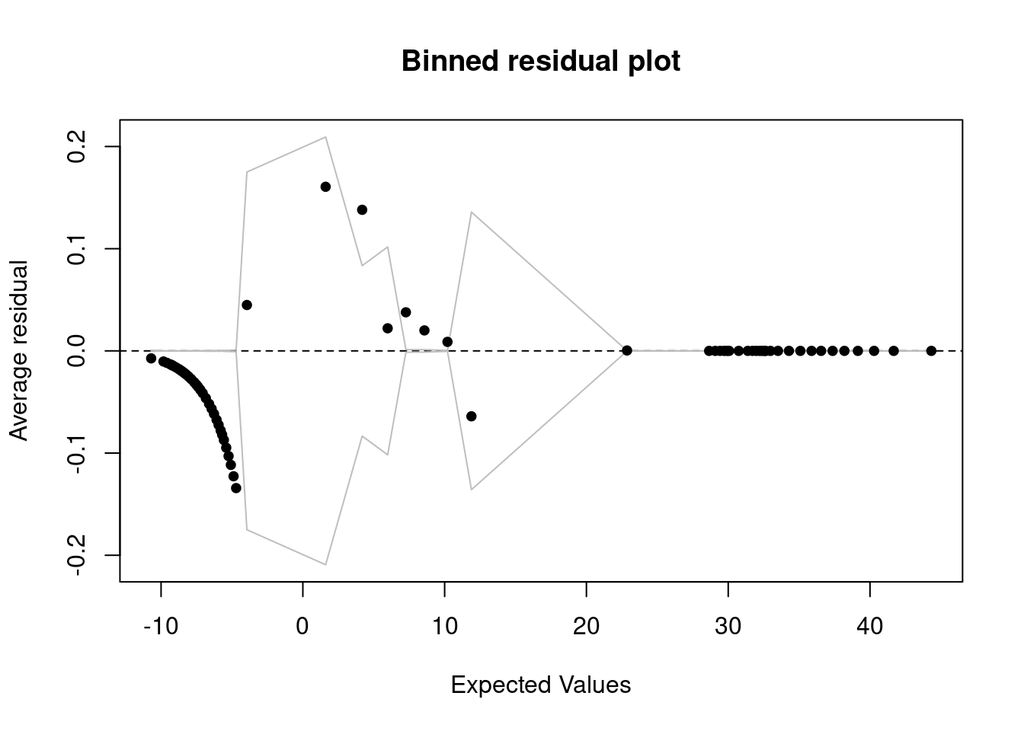

```r
library(arm)
x <- predict(m2)
y <- resid(m2)
binnedplot(x,y)
```

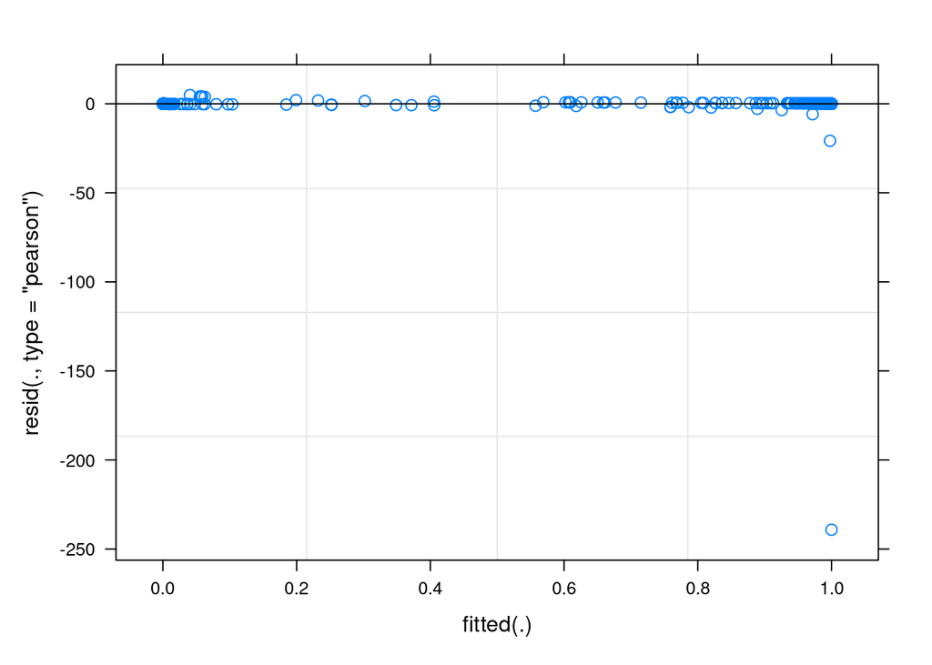

```r
plot(m2, which = 2)
```

```r
summ(m2, exp = T, scale = T)
```

```
## boundary (singular) fit: see ?isSingular
```

```
## MODEL INFO:
## Observations: 4785
## Dependent Variable: RT
## Type: Mixed effects generalized linear regression
## Error Distribution: binomial
## Link function: logit
##
## MODEL FIT:
## AIC = 174.89, BIC = 259.04
## Pseudo-R² (fixed effects) = 0.99
## Pseudo-R² (total) = 0.99
##
## FIXED EFFECTS:
## -------------------------------------------------------------
##                            exp(Est.)     S.E.   z val.      p
## ----------------- ------------------ -------- -------- ------
## (Intercept)                     0.00     0.69    -8.40   0.00
## DAST3                         782.11     0.70     9.57   0.00
## DAST4               9756130288500.36   205.32     0.15   0.88
## DAST5               4707311192329.70   145.18     0.20   0.84
## AUDIT2                          0.03     1.14    -3.00   0.00
## AUDIT3                         32.21     0.80     4.36   0.00
## ANYALC                          4.31     0.44     3.32   0.00
## log(AGE)                        3.33     0.37     3.27   0.00
## ALCDRUGS                        0.45     0.64    -1.26   0.21
## BINGEDAYS                       6.80     0.41     4.68   0.00
## COSCREEN                       14.54     0.66     4.06   0.00
## -------------------------------------------------------------
##
## RANDOM EFFECTS:
## -----------------------------------
##   Group     Parameter    Std. Dev.
## --------- ------------- -----------
##  VET:SEX   (Intercept)     0.00
##    SEX     (Intercept)     0.33
## -----------------------------------
##
## Grouping variables:
## ---------------------------
##   Group    # groups   ICC
## --------- ---------- ------
##  VET:SEX      5       0.00
##    SEX        3       0.03
## ---------------------------
##
## Continuous predictors are mean-centered and scaled by 1 s.d.
```

```r
VarCorr(m2)
```

```
##  Groups  Name        Std.Dev.
##  VET:SEX (Intercept) 0.00000
##  SEX     (Intercept) 0.32788
```

```r
#confint(m2, parm = "theta_", oldNames = FALSE)
```

## Third: random slope of (DAST+ VET) within group (SEX) with correlated intercept

```r
m3 <- glmer(RT~DAST+AUDIT+ANYALC+log(AGE)+ALCDRUGS+BINGEDAYS+COSCREEN+(1+DAST+VET|SEX), data =newdata, family =  binomial(link = "logit"))
summary(m3)
```

```
## Generalized linear mixed model fit by maximum likelihood (Laplace
##   Approximation) [glmerMod]
##  Family: binomial  ( logit )
## Formula: RT ~ DAST + AUDIT + ANYALC + log(AGE) + ALCDRUGS + BINGEDAYS +
##     COSCREEN + (1 + DAST + VET | SEX)
##    Data: newdata
##
##      AIC      BIC   logLik deviance df.resid
##    200.4    368.7    -74.2    148.4     4759
##
## Scaled residuals:
##      Min       1Q   Median       3Q      Max
## -228.386   -0.026   -0.007    0.000    5.083
##
## Random effects:
##  Groups Name        Variance Std.Dev. Corr
##  SEX    (Intercept) 0.07744  0.2783
##         DAST3       0.18290  0.4277    1.00
##         DAST4       0.98018  0.9900    0.42  0.42
##         DAST5       1.56114  1.2495    0.16  0.16  0.00
##         VET1        0.02002  0.1415   -1.00 -1.00 -0.41 -0.16
## Number of obs: 4785, groups:  SEX, 3
##
## Fixed effects:
##               Estimate Std. Error z value Pr(>|z|)
## (Intercept) -2.006e+01  4.570e+00  -4.389 1.14e-05 ***
## DAST3        6.459e+00  7.679e-01   8.411  < 2e-16 ***
## DAST4        3.343e+01  3.267e+04   0.001 0.999184
## DAST5        2.892e+01  4.881e+03   0.006 0.995272
## AUDIT2      -3.404e+00  1.156e+00  -2.944 0.003242 **
## AUDIT3       3.457e+00  7.845e-01   4.406 1.05e-05 ***
## ANYALC       1.763e-01  5.137e-02   3.431 0.000601 ***
## log(AGE)     3.522e+00  1.101e+00   3.200 0.001376 **
## ALCDRUGS    -1.480e-01  1.151e-01  -1.286 0.198446
## BINGEDAYS    3.379e-01  7.353e-02   4.596 4.30e-06 ***
## COSCREEN1    2.693e+00  6.495e-01   4.146 3.39e-05 ***
## ---
## Signif. codes:  0 '***' 0.001 '**' 0.01 '*' 0.05 '.' 0.1 ' ' 1
##
## Correlation of Fixed Effects:
##           (Intr) DAST3  DAST4  DAST5  AUDIT2 AUDIT3 ANYALC l(AGE) ALCDRU BINGED
## DAST3     -0.435
## DAST4      0.000  0.000
## DAST5      0.000  0.000  0.000
## AUDIT2    -0.005  0.054  0.000  0.000
## AUDIT3    -0.351  0.268  0.000  0.000  0.260
## ANYALC    -0.271  0.122  0.000  0.000 -0.288 -0.247
## log(AGE)  -0.995  0.403  0.000  0.000  0.006  0.334  0.249
## ALCDRUGS   0.219 -0.400  0.000  0.000 -0.025  0.088 -0.614 -0.204
## BINGEDAYS -0.156  0.276  0.000  0.000 -0.118  0.039 -0.288  0.135  0.122
## COSCREEN1 -0.315  0.034  0.000  0.000 -0.163 -0.031  0.148  0.302 -0.134 -0.048
## optimizer (Nelder_Mead) convergence code: 4 (failure to converge in 10000 evaluations)
## unable to evaluate scaled gradient
## Model failed to converge: degenerate  Hessian with 3 negative eigenvalues
## failure to converge in 10000 evaluations
```

```r
((0.18290+0.07744+0.98018+1.56114)/((0.18290+0.07744+0.98018+1.56114)+pi^2/3))*100
```

```
## [1] 45.99273
```